# Homework 4

Michael Anderson

manderson113@student.gsu.edu

002485269

```python
import pandas as pd
import numpy as np
import pandas_profiling
import matplotlib.pyplot as plt
from sklearn import preprocessing
%matplotlib inline
```

# 1

## a)

### Conditional Probability

$p(A|B)$

Probability of A given B

Given that B is true, what is the probability of A?

*Given that you drew a face card, what is the probability it is a King?*

$p(\textrm{King}|\textrm{Face}) = \frac{4}{12} = \frac{1}{3}$

### Marginal Probability

$p(A)$

The probability of an event occuring that not conditioned on another event, the "unconditional probability".

*What is the probability of rolling a six on a six-sided die?*

$p(6) = \frac{1}{6}$

### Joint Probability

$p(A \cap B)$

The probability of two events both occuring at the same time.

*What is the probability of a card is an ace and is red?*

$p(\textrm{ace} \cap \textrm{red}) = \frac{2}{52} = \frac{1}{26}$

## b)

### Baye's rule

$P(A|B) = \frac{P(B|A) \times P(A)}{P(B)}$

Baye's rule describes how to update a belief based on existing evidence.

We use prior knowledge of conditions to form a more accurate understanding of the probability of an event occuring.

#### prior

$P(A)$

The probability before the evidence is considered.

#### posterior

$P(A|B)$

The updated probability after the evidence is considered.

#### likelihood

$P(B|A)$

The probability of the evidence, given the belief is true.

#### marginal probability

$P(B)$

The probability of the evidence, under any circumstance.

## c)

### Naive Bayes

$P(X_{1}...X_{n}|Y) = \prod_{i} P(X_{i}|Y)$

Naive Bayes assumes that $X_{i}$ and $X_{j}$ are conditionally independent given $Y$, for all $i \neq j$.

Basically, we 'naively' assume that every feature is independent of the other features, and that all the features have the same weight. While this is almost always not the case, in reduces the number of parameters needed to describe the probability from $(2^{n}-1)*2 + 1$ to $2n + 1$, and is **much** faster.

# 2

```python
cars = pd.read_csv("data/cars.csv")
```

```python
cars
```

|  | Color | Type | Origin | Stolen? |
| --- | --- | --- | --- | --- |
| 0 | Red | Sports | Domestic | Yes |
| 1 | Red | Sports | Domestic | No |
| 2 | Red | Sports | Domestic | Yes |
| 3 | Yellow | Sports | Domestic | No |
| 4 | Yellow | Sports | Imported | Yes |
| 5 | Yellow | SUV | Imported | No |
| 6 | Yellow | SUV | Imported | Yes |
| 7 | Yellow | SUV | Domestic | No |
| 8 | Red | SUV | Imported | No |
| 9 | Red | Sports | Imported | Yes |

```python
# Import LabelEncoder
from sklearn import preprocessing
#creating labelEncoder
le = preprocessing.LabelEncoder()
```

```python
cars_encoded = cars.apply(le.fit_transform)
cars_encoded
```

|  | Color | Type | Origin | Stolen? |
| --- | --- | --- | --- | --- |
| 0 | 0 | 1 | 0 | 1 |
| 1 | 0 | 1 | 0 | 0 |
| 2 | 0 | 1 | 0 | 1 |
| 3 | 1 | 1 | 0 | 0 |
| 4 | 1 | 1 | 1 | 1 |
| 5 | 1 | 0 | 1 | 0 |
| 6 | 1 | 0 | 1 | 1 |
| 7 | 1 | 0 | 0 | 0 |
| 8 | 0 | 0 | 1 | 0 |
| 9 | 0 | 1 | 1 | 1 |

```python
for column in cars:
    labels = {}
    for c,ce in zip(cars[column], cars_encoded[column]):
        labels[c] = ce
    print(column)
    for k,v in labels.items():
        print(f"{k:>{8}}: {v}")
    print()
```

```
Color
     Red: 0
  Yellow: 1

Type
  Sports: 1
     SUV: 0

Origin
Domestic: 0
Imported: 1

Stolen?
     Yes: 1
      No: 0
```

```python
features = []
label = []
for index, row in cars_encoded.iterrows():
    features.append(tuple(row.values[:-1]))
    label.append(row.values[-1])
labels = np.array(label)
print(features)
print(label)
```

```
[(0, 1, 0), (0, 1, 0), (0, 1, 0), (1, 1, 0), (1, 1, 1), (1, 0, 1), (1, 0, 1), (1, 0, 0), (0, 0, 1), (0, 1, 1)]
[1, 0, 1, 0, 1, 0, 1, 0, 0, 1]
```

```python
#Import Gaussian Naive Bayes model
from sklearn.naive_bayes import MultinomialNB

#Create a Gaussian Classifier
model = MultinomialNB()

# Train the model using the training sets
model.fit(features,label)

#Predict Output

predicted= model.predict([[0,0,0]])

print(f"Will the Red Domestic SUV be stolen? {'Yes' if predicted[0] else 'No'}")
```

```
Will the Red Domestic SUV be stolen? No
```

This model predicts that a Red Domestic SUV is not likely to be stolen.

# 3

```python
le = preprocessing.LabelEncoder()
data = pd.read_csv("data/problem3.csv")
data.profile_report()
```

[interactive chart not shown]

```python
variables = list(data.columns)
target = 'income'
variables.remove(target)
data['workclass'].replace(' ?', data['workclass'].mode()[0], inplace=True)
data['occupation'].replace(' ?', data['occupation'].mode()[0], inplace=True)
data['native_country'].replace(' ?', data['native_country'].mode()[0], inplace=True)
```

```python
to_encode = ['workclass', 'education', 'marital_status', 'occupation', 'relationship', 'race', 'sex', 'native_country']
for name in to_encode:
    data[name] = le.fit_transform(data[name])
```

```python
from sklearn.naive_bayes import GaussianNB
model = GaussianNB()
```

```python
train = data.sample(frac = 0.7)
test = data.drop(train.index)
```

```python
model.fit(train[variables],train[target])
```

```
GaussianNB()
```

```python
from sklearn import metrics
import seaborn as sns
def analyze(actual, predicted):
    cm = metrics.confusion_matrix(actual, predicted)
    print(cm)
    tn, fp, fn, tp = cm.ravel()
    analysis = {}
    analysis["true_positive"] = tp
    analysis["true_negative"] = tn
    analysis["false_positive"] = fp
    analysis["false_negative"] = fn
    analysis["accuracy"] = (tp+tn)/(tp+tn+fp+fn)
    analysis["missclassification"] = 1 - analysis["accuracy"]
    analysis["sensitivity"] = tp/(tp+fn)
    analysis["specificity"] = tn/(tn+fp)
    analysis["positive_prediction_value"] = tp/(tp+fp)
    analysis["negative_prediction_value"] = tn/(tn+fn)
    analysis["positive_likelihood_ratio"] = analysis["sensitivity"]/(1-analysis["specificity"])
    analysis["negative_likelihood_ratio"] = 1/analysis["positive_likelihood_ratio"]
    length = max(len(key) for key in analysis) + 1
    for key, val in analysis.items():
        name = f"{key.replace('_',' ').title()}:"
        print(f"{name: <{length}} {round(val,2)}")
    print()
    group_names = ["True Neg","False Pos","False Neg","True Pos"]
    group_counts = ["{0:0.0f}".format(value) for value in cm.flatten()]
    group_percentages = ["{0:.2%}".format(value) for value in cm.flatten()/np.sum(cm)]
    labels = [f"{v1}\n{v2}\n{v3}" for v1, v2, v3 in zip(group_names,group_counts,group_percentages)]
    labels = np.asarray(labels).reshape(2,2)
    sns.heatmap(cm, annot=labels, fmt="", cmap='Blues', cbar=False)
    print()
    report = metrics.classification_report(actual, predicted)
    print(report)
```

## Training Set

```
[[16358   900]
 [ 3785  1749]]
True Positive:             1749
True Negative:             16358
False Positive:            900
False Negative:            3785
Accuracy:                  0.79
Missclassification:        0.21
Sensitivity:               0.32
Specificity:               0.95
Positive Prediction Value: 0.66
Negative Prediction Value: 0.81
Positive Likelihood Ratio: 6.06
Negative Likelihood Ratio: 0.17


              precision    recall  f1-score   support

       <=50K       0.81      0.95      0.87     17258
        >50K       0.66      0.32      0.43      5534

    accuracy                           0.79     22792
   macro avg       0.74      0.63      0.65     22792
weighted avg       0.78      0.79      0.77     22792
```

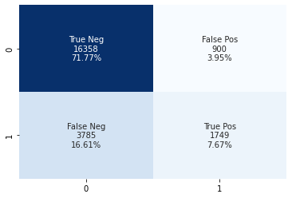

```python
analyze(train[target], model.predict(train[variables]))
```

## Test Set

```
[[7056  405]
 [1612  695]]
True Positive:             695
True Negative:             7056
False Positive:            405
False Negative:            1612
Accuracy:                  0.79
Missclassification:        0.21
Sensitivity:               0.3
Specificity:               0.95
Positive Prediction Value: 0.63
Negative Prediction Value: 0.81
Positive Likelihood Ratio: 5.55
Negative Likelihood Ratio: 0.18


              precision    recall  f1-score   support

       <=50K       0.81      0.95      0.87      7461
        >50K       0.63      0.30      0.41      2307

    accuracy                           0.79      9768
   macro avg       0.72      0.62      0.64      9768
weighted avg       0.77      0.79      0.76      9768
```

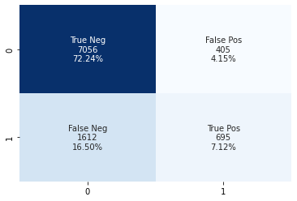

```python
predicted = model.predict(test[variables])
analyze(test[target], predicted)
```

```python
probabilities = model.predict_proba(test[variables])
```

```python
probabilities
```

```
array([[0.99521393, 0.00478607],
       [0.9865689 , 0.0134311 ],
       [0.99450348, 0.00549652],
       ...,
       [0.99690781, 0.00309219],
       [0.99561231, 0.00438769],
       [0.9889404 , 0.0110596 ]])
```

```python
less = probabilities[:,0]
more = probabilities[:,1]
```

```python
df = pd.DataFrame({
    "<=50k": less,
    ">50k": more
})
```

```
array([[<AxesSubplot:title={'center':'<=50k'}>,
        <AxesSubplot:title={'center':'>50k'}>]], dtype=object)
```

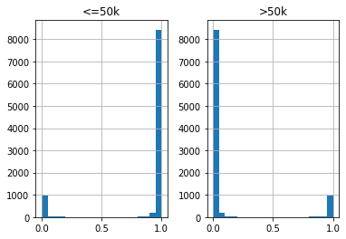

```python
df.hist(bins=20)
```

For the vast majority of items in the test set, this model was confident in it's classification of the income bracket.